# Practical 2

### Question 1

We start by generating samples from a normal distribution:

```
xpop=rnorm(10000,50,6)
```

If unsure with this command use ?rnorm to check how it works.

Now we can use the command sample to create 100 samples each of size 4.

```
x1=sample(xpop,100,replace=FALSE)
x2=sample(xpop,100,replace=FALSE)
x3=sample(xpop,100,replace=FALSE)
x4=sample(xpop,100,replace=FALSE)
```

We will combine these samples into a matrix

```
m1=cbind(x1,x2,x3,x4)
```

We can look at the mean of each sample using the code:

```
xbar=apply(m1,1,mean)
xbar
```

```
  [1] 48.28662 49.15098 52.82860 55.38578 50.45276 50.03731
  [7] 45.79173 48.51741 50.82779 51.21256 49.35778 46.20197
 [13] 53.53874 50.08599 55.07500 54.79400 48.26301 42.62911
 [19] 50.93044 48.10170 53.52068 50.85013 50.39465 47.33062
 [25] 50.53925 47.41408 44.70355 47.25861 47.22929 47.42065
 [31] 50.17673 49.74505 48.18619 49.39351 43.89391 46.53632
 [37] 52.66095 47.99845 47.92843 45.27375 50.26878 53.04201
 [43] 47.77754 53.98618 51.92533 45.09864 49.57493 52.64883
 [49] 48.47614 56.97984 52.55546 51.10919 47.08994 46.38921
 [55] 52.67165 45.13486 53.30947 50.78081 51.49149 52.65539
 [61] 47.36070 49.65016 54.42922 53.27045 55.66682 48.42283
 [67] 49.29455 50.09654 54.83017 50.65775 50.64006 48.36190
 [73] 51.52755 44.86950 50.98737 52.67309 48.21393 53.18929
 [79] 47.41600 43.36104 48.14718 55.16630 48.07186 48.53980
 [85] 54.10255 50.33033 53.29720 44.53629 51.85499 46.90849
 [91] 47.60079 47.65489 47.19917 47.70118 53.29479 47.73676
 [97] 50.06222 50.05174 52.25513 50.36926
```

Here we have a list of 100 values each giving the mean of a sample of size 4.

In order to justify whether the central limit holds in the case of samples of size 4 there are 3 things we need to check about the sample mean:

- The mean, this should be the same as the population mean, $\mu$;
- The variance, this should be the population variance divided by sample size, $\frac{\sigma^2}{n}$;
- The distribution, this should be a normal distribution

First, let us check the mean. The mean of the expected value of the population is

```
mean(xpop)
```

```
[1] 50.08732
```

Note in this case we know we simulated the population from a normal random variable with mean $50$. We can compare this with mean of the sample means:

```
mean(xbar)
```

```
[1] 49.8269
```

As we can see here the mean of the sample mean is very close to the population mean, if we needed more accuracy we could take more than 100 copies of each sample.

Next let us compare the vaiance. According to the central limit theorem the variance should be given by $\sigma^2/n$, in this case this is given by

```
var(xpop)/4
```

```
[1] 9.103641
```

Due to how we constructed the population we know this should be approximately $6^2/4=9$. Compare this to the variance of the sample mean:

```
var(xbar)
```

```
[1] 9.246487
```

To assess the distribution we look at the histogram, boxplots and the Q-Q plot. We will plot histograms on the same scale using the command xlim

```
par(mfrow=c(1,2)) #To split the graphics into two columns
hist(xpop,xlim=c(20,80))
hist(xbar,xlim=c(20,80))
```

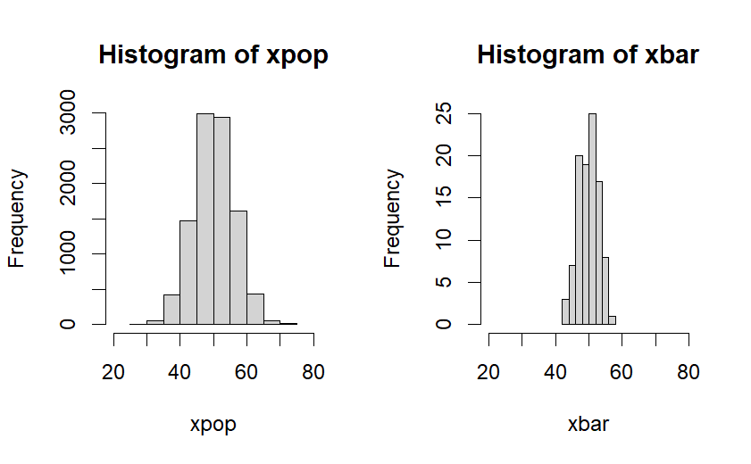

Note it is important here to use the same scale so we can easily see differences in the variance. We are using xpop here as the population (although really it is just an extrememly large sample.

The histogram does not give us any reason to doubt that the distribution is normally distributed.

```
boxplot(xpop,xbar, names=c("Population","Sample Mean"),horizontal = TRUE)
```

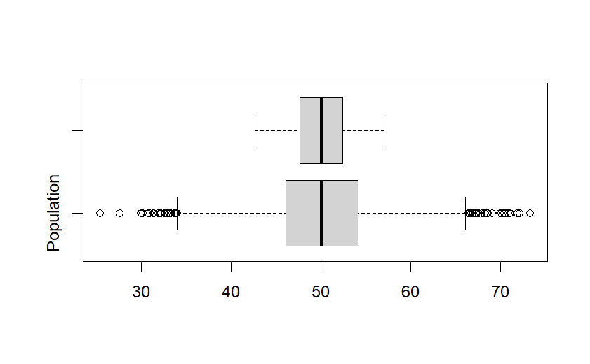

We see that the distribution is roughly symmetrical so again this is consistent with the normal distribution.

Finally we draw a Q-Q plot

```
qqnorm(xbar)
qqline(xbar) # Line of best fit to help with the comparison
```

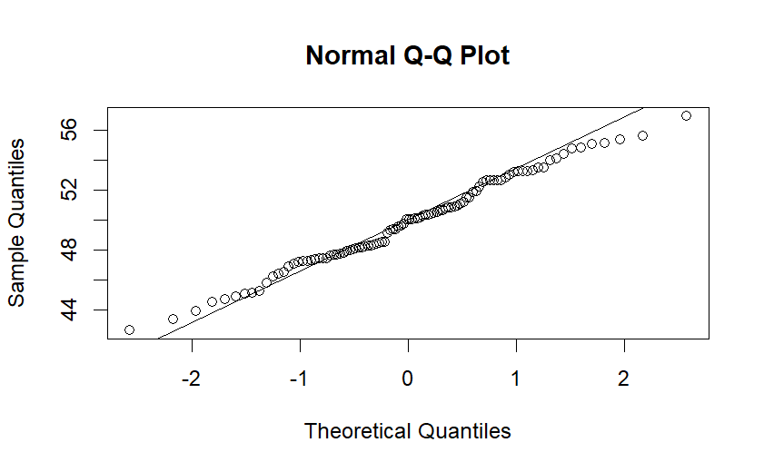

We see that the sample mean data is very close to a straight line in the Q-Q plot which means that the data is likely to be from a normal distribution.

Therefore we can verify that the central limit theorem holds in this case.

If we take samples of size 9 from a normal random variable we will see the same behaviour.

### Question 2

Simulate $\texttt{nsim}=10^4$ samples of size $n=6$ from a $\mathrm{Gamma}(2,1)$ distribution. For each sample calculate
$$\hat{\theta}_1=\bar{X}, \quad \hat{\theta}_2 =
\frac{9}{30}(X_1+X_2+X_3)+\frac{1}{30}(X_4+X_5+X_6)$$

```
nsim = 10^4
# Initialise vectors as arrays of 0's
theta.1 = rep(0, nsim)
theta.2 = rep(0, nsim)
for (i in 1:nsim) {
x = rgamma(n = 6, shape = 2, rate = 1)
theta.1[i] = mean(x)
theta.2[i] = (9/30) * sum(x[1:3]) + (1/30) * sum(x[4:6])
}
```

We want to verify that $\hat{\theta}_1=\bar{X}\sim \mathrm{Gamma}(12,6)$. We start by plotting a histogram

```
hist(theta.1,xlim=c(0,5),ylim=c(0,0.7),freq=F,main="")
title(main="Histogram of theta.1 and pdf of Gamma(12,6)")
```

```
# Then define a grid of values and add the line of the pdf values to plot
x.grid = seq(0.0001,5,length=1000)
lines(x.grid,dgamma(x.grid,shape=12,rate=6),col="red")
```

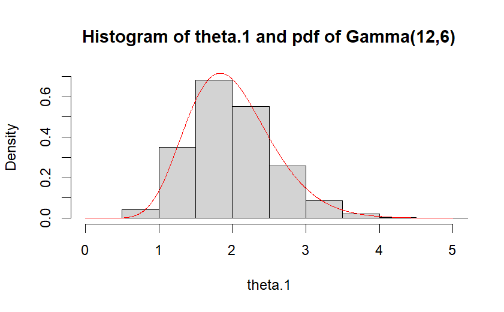

Since the pdf of $\mathrm{Gamma}(12,6)$ follows the shape of the histogram of theta.1 very well, the sampling distribution of $\hat{\theta}_1$ verifies the required rule.

Now for $\hat{\theta}_2$

```
par(mfrow=c(1,2))
hist(theta.1,xlim=c(0,5),freq=F)
hist(theta.2,xlim=c(0,5),freq=F)
```

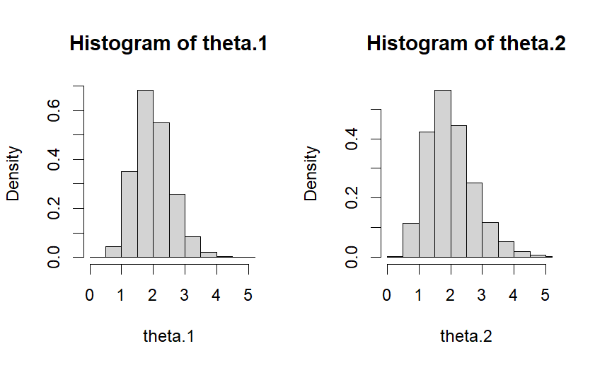

The simulation suggests that both estimators are unbiased, since their means are equal to $2$ (approximately). (Notice that these values will vary if you repeat the simulation - so the values you obtain will be slightly different! But they are, of course, estimates of the true means of the two sampling distributions - their accuracy will improve as $\texttt{nsim}$ gets larger). Since both estimators are unbiased, their variance will tell us about their MSE. The plots show that $\hat{\theta}_2$ has larger variance. Checking in R gives the following estimates of the mean and variance of the two sampling distributions:

```
mean(theta.1)
```

```
[1] 2.001446
```

```
mean(theta.2)
```

```
[1] 2.002381
```

```
var(theta.1)
```

```
[1] 0.3408764
```

```
var(theta.2)
```

```
[1] 0.5624426
```

### Question 3

```
nsim = 10^4
# Initialise vectors as arrays of 0's
theta.a = rep(0,nsim)
theta.b = rep(0,nsim)
for (i in 1:nsim){
x = runif(n=6,min=0,max=2)
theta.a[i] = 2*mean(x)
theta.b[i] = max(x)
}
```

```
mean(theta.a)
```

```
[1] 1.999532
```

```
mean(theta.b)
```

```
[1] 1.713668
```

The mean of $\hat{\theta}_1$ appears to be unbiased while $\hat{\theta}_2$ shows some bias.

```
var(theta.a)
```

```
[1] 0.2200539
```

```
var(theta.b)
```

```
[1] 0.06155407
```

The variance for $\hat{\theta}_2$ is much smaller than $\hat{\theta}_1$.

```
(mean(theta.a)-2)^2+var(theta.a)
```

```
[1] 0.2200541
```

```
(mean(theta.b)-2)^2+var(theta.b)
```

```
[1] 0.14354
```

Therefore $\hat{\theta}_b$ is more efficient then $\hat{\theta}_a$.

### Question 4

We are given the data

```
sample=c(3.9, 3.4, 5.2, 2.6, 3.4, 2.7, 3.1, 2.4, 4.2, 1.7, 2.4, 3.3, 2.3, 2.0, 3.4, 2.9, 2.5, 3.9, 2.3, 1.1)
```

```
n=length(sample)
mean_sam=mean(sample)
var_sam=var(sample)
alpha_hat=n*mean_sam^2/((n-1)*var_sam)
alpha_hat
```

```
[1] 10.19103
```

```
beta_hat=n*mean_sam/((n-1)*var_sam)
beta_hat
```

```
[1] 3.472243
```